# Analysis of Ames Housing Dataset

August 5th, 2022

# Introduction

# Methods

## 1.1. Data Cleaning

Let’s import and take a look at the structure of the data

```r
ames <- read.csv("AmesHousing.csv")
print(str(ames))
```

```
## 'data.frame':    2930 obs. of  82 variables:
##  $ Order          : int  1 2 3 4 5 6 7 8 9 10 ...
##  $ PID            : int  526301100 526350040 526351010 526353030 527105010 527105030 527127150 527145080 527146030 527162130 ...
##  $ MS.SubClass    : int  20 20 20 20 60 60 120 120 120 60 ...
##  $ MS.Zoning      : chr  "RL" "RH" "RL" "RL" ...
##  $ Lot.Frontage   : int  141 80 81 93 74 78 41 43 39 60 ...
##  $ Lot.Area       : int  31770 11622 14267 11160 13830 9978 4920 5005 5389 7500 ...
##  $ Street         : chr  "Pave" "Pave" "Pave" "Pave" ...
##  $ Alley          : chr  NA NA NA NA ...
##  $ Lot.Shape      : chr  "IR1" "Reg" "IR1" "Reg" ...
##  $ Land.Contour   : chr  "Lvl" "Lvl" "Lvl" "Lvl" ...
##  $ Utilities      : chr  "AllPub" "AllPub" "AllPub" "AllPub" ...
##  $ Lot.Config     : chr  "Corner" "Inside" "Corner" "Corner" ...
##  $ Land.Slope     : chr  "Gtl" "Gtl" "Gtl" "Gtl" ...
##  $ Neighborhood   : chr  "NAmes" "NAmes" "NAmes" "NAmes" ...
```

[output cut: 69 more lines]

### Some Observations

Observe that there are 82 different variables in the data. Some of them are numerical and some of them are cathegorical. We can also see some NA values in the data. Now to clean the data, we will apply the following operations in the next chunk:

1. Remove the near zero variance predictors
2. Remove Order (just the order of houses) and PID (unique house identifier)
3. Calculate the share of missing data for each column.
4. Seperate the cathegorical and numerical columns for missing data.

```r
# remove near zero variance predictors
nzv <- nearZeroVar(ames)
ames <- ames[, -nzv]

# remove Order (just the order of houses), PID (unique house identifier)
ames <- subset(ames, select = -c(Order, PID))

# get count and percentage of missing values in columns with missing values
na_count <- sapply(ames, function(y) sum(length(which(is.na(y)))))
na_count / nrow(ames)
```

```
##    MS.SubClass      MS.Zoning   Lot.Frontage       Lot.Area          Alley
##   0.0000000000   0.0000000000   0.1672354949   0.0000000000   0.9324232082
##      Lot.Shape     Lot.Config   Neighborhood    Condition.1      Bldg.Type
##   0.0000000000   0.0000000000   0.0000000000   0.0000000000   0.0000000000
##    House.Style   Overall.Qual   Overall.Cond     Year.Built Year.Remod.Add
##   0.0000000000   0.0000000000   0.0000000000   0.0000000000   0.0000000000
##     Roof.Style   Exterior.1st   Exterior.2nd   Mas.Vnr.Type   Mas.Vnr.Area
##   0.0000000000   0.0000000000   0.0000000000   0.0000000000   0.0078498294
##     Exter.Qual     Exter.Cond     Foundation      Bsmt.Qual  Bsmt.Exposure
##   0.0000000000   0.0000000000   0.0000000000   0.0269624573   0.0269624573
## BsmtFin.Type.1   BsmtFin.SF.1    Bsmt.Unf.SF  Total.Bsmt.SF     Heating.QC
##   0.0269624573   0.0003412969   0.0003412969   0.0003412969   0.0000000000
##    Central.Air     Electrical    X1st.Flr.SF    X2nd.Flr.SF    Gr.Liv.Area
##   0.0000000000   0.0000000000   0.0000000000   0.0000000000   0.0000000000
## Bsmt.Full.Bath Bsmt.Half.Bath      Full.Bath      Half.Bath  Bedroom.AbvGr
##   0.0006825939   0.0006825939   0.0000000000   0.0000000000   0.0000000000
##   Kitchen.Qual  TotRms.AbvGrd     Fireplaces   Fireplace.Qu    Garage.Type
##   0.0000000000   0.0000000000   0.0000000000   0.4853242321   0.0535836177
##  Garage.Yr.Blt  Garage.Finish    Garage.Cars    Garage.Area    Paved.Drive
##   0.0542662116   0.0535836177   0.0003412969   0.0003412969   0.0000000000
##   Wood.Deck.SF        Pool.QC          Fence   Misc.Feature        Mo.Sold
##   0.0000000000   0.9955631399   0.8047781570   0.9638225256   0.0000000000
##        Yr.Sold      Sale.Type Sale.Condition      SalePrice
##   0.0000000000   0.0000000000   0.0000000000   0.0000000000
```

```r
#get the number of columns with missing data that are numeric or factor
missing_data_columns <- subset(ames, select = names(na_count[na_count > 0]))
numerical_columns <- missing_data_columns[, unlist(lapply(missing_data_columns, is.numeric), use.names = FALSE)]
character_columns <- missing_data_columns[, unlist(lapply(missing_data_columns, is.character), use.names = FALSE)]

# get the number of columns with NA vaules:
print("# of numerical columns with NA values is:")
```

```
## [1] "# of numerical columns with NA values is:"
```

```r
print(length(numerical_columns))
```

```
## [1] 10
```

```r
print("# of cathegorical columns with NA values is:")
```

```
## [1] "# of cathegorical columns with NA values is:"
```

```r
print(length(character_columns))
```

```
## [1] 10
```

Now we will fill the NA values with appropriate values. Here is the details for each columns:

### Numerical columns:

Column Name (Default value I want to fill in for NA) “Lot.Frontage”(0), “Mas.Vnr.Area”(0), “BsmtFin.SF.1”(0), “Bsmt.Unf.SF”(0), “Total.Bsmt.SF”(0), “Bsmt.Full.Bath”(0), “Bsmt.Half.Bath”(0), “Garage.Yr.Blt”(Same as the YearBuilt), “Garage.Cars”(0), “Garage.Area”(0)

### Cathegorical Columns:

Column Name (Default value I want to fill in for NA) “Alley” (“None”), “Bsmt.Qual”(“No_Basement”), “Bsmt.Exposure”(“No_Basement”), “BsmtFin.Type.1”(“None”), “Fireplace.Qu”(“None”), “Garage.Type” (“None”), “Garage.Finish” (“None”),  
“Pool.QC”(“None”), “Fence” (“None”), “Misc.Feature” (“None”)

```r
### Numerical columns:

zero_value_columns <- c("Mas.Vnr.Area", "BsmtFin.SF.1", "Bsmt.Unf.SF", "Total.Bsmt.SF", "Bsmt.Full.Bath",
                        "Bsmt.Half.Bath","Garage.Cars", "Garage.Area", "Lot.Frontage")
ames[zero_value_columns][is.na(ames[zero_value_columns])] <- 0

ames$Garage.Yr.Blt <- ifelse(is.na(ames$Garage.Yr.Blt), ames$Year.Built, ames$Garage.Yr.Blt)

#Cathegorical columns:
none_columns = c("Alley", "BsmtFin.Type.1", "Fireplace.Qu", "Garage.Type",
                 "Garage.Finish", "Pool.QC", "Fence", "Misc.Feature")
no_basement_columns = c("Bsmt.Qual", "Bsmt.Exposure")

ames[none_columns][is.na(ames[none_columns])] <- "None"
ames[no_basement_columns][is.na(ames[no_basement_columns])] <- "No Basement"
```

Now we have handled the NA values. Thw next thing we will do is converting the categorical data to numerical values. There are two options for each categorical column, we can either convert it to a dummy variable or to a factorized variable if there is hierarchical relationship between elements. We should make our analysis one by one for each variable.

```r
str(ames[, unlist(lapply(ames, is.character), use.names = FALSE)])
```

```
## 'data.frame':    2930 obs. of  31 variables:
##  $ MS.Zoning     : chr  "RL" "RH" "RL" "RL" ...
##  $ Alley         : chr  "None" "None" "None" "None" ...
##  $ Lot.Shape     : chr  "IR1" "Reg" "IR1" "Reg" ...
##  $ Lot.Config    : chr  "Corner" "Inside" "Corner" "Corner" ...
##  $ Neighborhood  : chr  "NAmes" "NAmes" "NAmes" "NAmes" ...
##  $ Condition.1   : chr  "Norm" "Feedr" "Norm" "Norm" ...
##  $ Bldg.Type     : chr  "1Fam" "1Fam" "1Fam" "1Fam" ...
##  $ House.Style   : chr  "1Story" "1Story" "1Story" "1Story" ...
##  $ Roof.Style    : chr  "Hip" "Gable" "Hip" "Hip" ...
##  $ Exterior.1st  : chr  "BrkFace" "VinylSd" "Wd Sdng" "BrkFace" ...
##  $ Exterior.2nd  : chr  "Plywood" "VinylSd" "Wd Sdng" "BrkFace" ...
##  $ Mas.Vnr.Type  : chr  "Stone" "None" "BrkFace" "None" ...
##  $ Exter.Qual    : chr  "TA" "TA" "TA" "Gd" ...
##  $ Exter.Cond    : chr  "TA" "TA" "TA" "TA" ...
```

[output cut: 17 more lines]

As we see from above, there are 31 chategorical variable in the data. We will convert following variables to dummy and the remaining will be factorized.

#### Dummy variables:

MS.Zoning, Lot.Config, Neighborhood, Condition.1, Bldg.Type, House.Style, Roof.Style, Exterior.1st, Exterior.2nd, Mas.Vnr.Type, Foundation, Electrical, Garage.Type, Misc.Feature, Sale.Type, Sale.Condition

#### Factorized variables:

Alley, Lot.Shape, Exter.Qual, Exter.Cond, Bsmt.Qual, Bsmt.Exposure, BsmtFin.Type.1, Heating.QC, Central.Air, Kitchen.Qual, Fireplace.Qu, Garage.Finish, Paved.Drive, Pool.QC, Fence

```r
dum_var_names = c("MS.Zoning", "Lot.Config", "Neighborhood", "Condition.1", "Bldg.Type", "House.Style", "Roof.Style", "Exterior.1st", "Exterior.2nd", "Mas.Vnr.Type", "Foundation", "Electrical", "Garage.Type", "Misc.Feature", "Sale.Type", "Sale.Condition")

ames <- fastDummies::dummy_cols(ames,select_columns =dum_var_names, remove_first_dummy = TRUE)
ames <- ames[ , !(names(ames) %in% dum_var_names)]


# Factorizations:

ames$Alley          <- as.numeric(ordered(ames$Alley, levels = c("None", "Pave", "Grvl")))
ames$Lot.Shape      <- as.numeric(ordered(ames$Lot.Shape, levels = c("IR3", "IR2", "IR1", "Reg")))
ames$Exter.Qual     <- as.numeric(ordered(ames$Exter.Qual, levels = c("Po", "Fa", "TA", "Gd", "Ex")))
ames$Exter.Cond     <- as.numeric(ordered(ames$Exter.Cond, levels = c("Po", "Fa", "TA", "Gd", "Ex")))
ames$Bsmt.Qual      <- as.numeric(ordered(ames$Bsmt.Qual, levels = c("No Basement", "Po", "Fa", "TA", "Gd", "Ex")))
ames$Bsmt.Exposure  <- as.numeric(ordered(ames$Bsmt.Exposure, levels = c("No Basement", "No", "Mn", "Av", "Gd")))
ames$BsmtFin.Type.1 <- as.numeric(ordered(ames$BsmtFin.Type.1, levels = c("None", "Unf", "LwQ", "Rec", "BLQ", "ALQ", "GLQ")))

ames$Heating.QC   <- as.numeric(ordered(ames$Heating.QC, levels = c("Po", "Fa", "TA", "Gd", "Ex")))
ames$Central.Air  <- as.numeric(ordered(ames$Central.Air, levels = c("N", "Y")))
ames$Kitchen.Qual <- as.numeric(ordered(ames$Kitchen.Qual, levels = c("Po", "Fa", "TA", "Gd", "Ex")))
ames$Fireplace.Qu <- as.numeric(ordered(ames$Fireplace.Qu, levels = c("None","Po", "Fa", "TA", "Gd", "Ex")))
ames$Garage.Finish<- as.numeric(ordered(ames$Garage.Finish, levels = c("None", "Unf", "RFn", "Fin")))
ames$Paved.Drive  <- as.numeric(ordered(ames$Paved.Drive, levels = c("N", "Y")))
ames$Pool.QC      <- as.numeric(ordered(ames$Pool.QC, levels = c("None", "Fa", "TA", "Gd", "Ex")))
ames$Fence        <- as.numeric(ordered(ames$Fence, levels = c("None", "MnWw", "GdWo", "MnPrv", "GdPrv")))
```

Now the data is ready for modelling.

## 1.2. Modelling:

### Train Test Split:

```r
set.seed(1)
ames_trn_idx  = sample(nrow(ames), size = trunc(0.70 * nrow(ames)))
ames_trn_data = ames[ames_trn_idx, ]
ames_tst_data = ames[-ames_trn_idx, ]
```

### Base model:

We will first construct a base model with all variables in X.

```r
model1 <- lm(SalePrice ~., data = ames_trn_data)
summary(model1)
```

```
##
## Call:
## lm(formula = SalePrice ~ ., data = ames_trn_data)
##
## Residuals:
##     Min      1Q  Median      3Q     Max
## -375535  -11450     -98   10545  213267
##
## Coefficients: (3 not defined because of singularities)
##                          Estimate Std. Error t value Pr(>|t|)
## (Intercept)            -4.410e+05  9.348e+05  -0.472 0.637181
## MS.SubClass            -7.633e+01  6.952e+01  -1.098 0.272385
## Lot.Frontage            4.175e+01  2.064e+01   2.023 0.043249 *
## Lot.Area                3.429e-01  8.171e-02   4.197 2.84e-05 ***
## Alley                   1.192e+03  1.799e+03   0.663 0.507514
## Lot.Shape              -1.891e+03  1.234e+03  -1.532 0.125620
## Overall.Qual            9.283e+03  8.820e+02  10.525  < 2e-16 ***
## Overall.Cond            5.390e+03  7.654e+02   7.043 2.65e-12 ***
## Year.Built              2.866e+02  7.466e+01   3.838 0.000128 ***
## Year.Remod.Add         -2.835e+01  4.940e+01  -0.574 0.566057
## Mas.Vnr.Area            3.148e+01  5.206e+00   6.047 1.78e-09 ***
## Exter.Qual              4.982e+03  1.845e+03   2.700 0.006991 **
## Exter.Cond              1.314e+03  1.867e+03   0.704 0.481616
## Bsmt.Qual               3.824e+03  1.350e+03   2.834 0.004653 **
## Bsmt.Exposure           5.369e+03  7.513e+02   7.146 1.28e-12 ***
## BsmtFin.Type.1         -8.821e+01  4.573e+02  -0.193 0.847061
## BsmtFin.SF.1            1.210e+01  3.736e+00   3.239 0.001222 **
## Bsmt.Unf.SF            -9.049e+00  3.762e+00  -2.405 0.016263 *
## Total.Bsmt.SF           1.763e+01  4.771e+00   3.694 0.000227 ***
## Heating.QC              1.299e+03  8.446e+02   1.538 0.124172
## Central.Air            -4.674e+03  3.284e+03  -1.423 0.154825
## X1st.Flr.SF             1.783e+01  1.868e+01   0.955 0.339799
## X2nd.Flr.SF             2.270e+01  1.802e+01   1.260 0.207856
## Gr.Liv.Area             4.053e+01  1.839e+01   2.204 0.027655 *
## Bsmt.Full.Bath          1.946e+03  1.710e+03   1.138 0.255175
## Bsmt.Half.Bath         -1.161e+03  2.660e+03  -0.436 0.662695
## Full.Bath               2.072e+03  1.909e+03   1.085 0.277984
## Half.Bath               3.891e+03  1.839e+03   2.116 0.034453 *
## Bedroom.AbvGr          -4.911e+03  1.220e+03  -4.026 5.90e-05 ***
## Kitchen.Qual            7.933e+03  1.476e+03   5.375 8.64e-08 ***
```

[output cut: 137 more lines]

```
## Sale.Type_Oth          -5.150e+03  1.349e+04  -0.382 0.702603
## Sale.Type_VWD           3.840e+03  2.603e+04   0.148 0.882731
## `Sale.Type_WD `         3.441e+03  3.955e+03   0.870 0.384334
## Sale.Condition_AdjLand  1.526e+04  1.258e+04   1.213 0.225382
## Sale.Condition_Alloca   5.382e+03  7.372e+03   0.730 0.465388
## Sale.Condition_Family   5.197e+03  6.243e+03   0.833 0.405187
## Sale.Condition_Normal   7.920e+03  2.587e+03   3.062 0.002232 **
## Sale.Condition_Partial -8.643e+02  1.230e+04  -0.070 0.943979
## ---
## Signif. codes:  0 '***' 0.001 '**' 0.01 '*' 0.05 '.' 0.1 ' ' 1
##
## Residual standard error: 24950 on 1836 degrees of freedom
##   (43 observations deleted due to missingness)
## Multiple R-squared:  0.9122, Adjusted R-squared:  0.9041
## F-statistic: 111.6 on 171 and 1836 DF,  p-value: < 2.2e-16
```

Build a new model by dropping the insignificant variables.

```r
vars_to_drop <- c("MS.SubClass", "Alley", "Lot.Shape", "Year.Remod.Add", "Exter.Cond", "Heating.QC", "Central.Air", "X1st.Flr.SF", "X2nd.Flr.SF", "Bsmt.Full.Bath", "Bsmt.Half.Bath", "Full.Bath", "TotRms.AbvGrd", "Fireplaces", "Fireplace.Qu", "Garage.Yr.Blt", "Garage.Finish", "Paved.Drive", "Fence", "Mo.Sold", "Yr.Sold", "`MS.Zoning_C (all)`","MS.Zoning_FV", "`MS.Zoning_I (all)`", "MS.Zoning_RH", "MS.Zoning_RL", "MS.Zoning_RM", "Electrical_FuseA", "Electrical_FuseF", "Electrical_FuseP", "Electrical_Mix", "Electrical_SBrkr" )

model2 <- lm(SalePrice ~. -MS.SubClass - Alley - Lot.Shape - Year.Remod.Add - Exter.Cond - Heating.QC - Central.Air - X1st.Flr.SF - X2nd.Flr.SF - Bsmt.Full.Bath - Bsmt.Half.Bath - Full.Bath - TotRms.AbvGrd - Fireplaces - Fireplace.Qu - Garage.Yr.Blt -  Garage.Finish - Paved.Drive - Fence - Mo.Sold - Yr.Sold - `MS.Zoning_C (all)` - MS.Zoning_FV - `MS.Zoning_I (all)` -  MS.Zoning_RH - MS.Zoning_RL - MS.Zoning_RM - Electrical_FuseA - Electrical_FuseF - Electrical_FuseP - Electrical_Mix - Electrical_SBrkr
             , data = ames_trn_data)

summary(model2)
```

```
##
## Call:
## lm(formula = SalePrice ~ . - MS.SubClass - Alley - Lot.Shape -
##     Year.Remod.Add - Exter.Cond - Heating.QC - Central.Air -
##     X1st.Flr.SF - X2nd.Flr.SF - Bsmt.Full.Bath - Bsmt.Half.Bath -
##     Full.Bath - TotRms.AbvGrd - Fireplaces - Fireplace.Qu - Garage.Yr.Blt -
##     Garage.Finish - Paved.Drive - Fence - Mo.Sold - Yr.Sold -
##     `MS.Zoning_C (all)` - MS.Zoning_FV - `MS.Zoning_I (all)` -
##     MS.Zoning_RH - MS.Zoning_RL - MS.Zoning_RM - Electrical_FuseA -
##     Electrical_FuseF - Electrical_FuseP - Electrical_Mix - Electrical_SBrkr,
##     data = ames_trn_data)
##
## Residuals:
##     Min      1Q  Median      3Q     Max
## -379975  -11464     -69   10683  212124
##
## Coefficients: (2 not defined because of singularities)
##                          Estimate Std. Error t value Pr(>|t|)
## (Intercept)            -1.267e+06  1.246e+05 -10.163  < 2e-16 ***
## Lot.Frontage            3.423e+01  2.014e+01   1.700 0.089345 .
## Lot.Area                3.560e-01  7.817e-02   4.554 5.59e-06 ***
## Overall.Qual            9.516e+03  8.596e+02  11.071  < 2e-16 ***
## Overall.Cond            5.387e+03  6.580e+02   8.187 4.89e-16 ***
## Year.Built              2.983e+02  6.206e+01   4.807 1.66e-06 ***
## Mas.Vnr.Area            3.096e+01  5.161e+00   5.999 2.37e-09 ***
## Exter.Qual              4.881e+03  1.814e+03   2.691 0.007182 **
## Bsmt.Qual               4.133e+03  1.310e+03   3.155 0.001629 **
## Bsmt.Exposure           5.266e+03  7.347e+02   7.168 1.09e-12 ***
## BsmtFin.Type.1          1.027e+02  4.397e+02   0.234 0.815387
## BsmtFin.SF.1            1.128e+01  3.682e+00   3.063 0.002224 **
## Bsmt.Unf.SF            -1.104e+01  3.519e+00  -3.137 0.001733 **
## Total.Bsmt.SF           1.786e+01  4.328e+00   4.128 3.82e-05 ***
## Gr.Liv.Area             6.378e+01  2.877e+00  22.166  < 2e-16 ***
## Half.Bath               3.700e+03  1.658e+03   2.231 0.025804 *
## Bedroom.AbvGr          -4.881e+03  1.090e+03  -4.478 8.00e-06 ***
## Kitchen.Qual            8.062e+03  1.425e+03   5.657 1.78e-08 ***
## Garage.Cars             6.101e+03  1.983e+03   3.077 0.002122 **
## Garage.Area             1.347e+01  6.572e+00   2.049 0.040573 *
## Wood.Deck.SF            1.005e+01  4.930e+00   2.039 0.041560 *
## Pool.QC                 1.857e+04  2.998e+03   6.193 7.22e-10 ***
```

[output cut: 113 more lines]

```
## Sale.Type_Oth          -5.314e+03  1.332e+04  -0.399 0.690102
## Sale.Type_VWD           4.573e+03  2.581e+04   0.177 0.859365
## `Sale.Type_WD `         4.209e+03  3.903e+03   1.078 0.281046
## Sale.Condition_AdjLand  1.764e+04  1.217e+04   1.450 0.147295
## Sale.Condition_Alloca   3.803e+03  7.191e+03   0.529 0.596937
## Sale.Condition_Family   6.191e+03  6.177e+03   1.002 0.316344
## Sale.Condition_Normal   8.253e+03  2.539e+03   3.250 0.001174 **
## Sale.Condition_Partial  1.601e+03  1.218e+04   0.131 0.895400
## ---
## Signif. codes:  0 '***' 0.001 '**' 0.01 '*' 0.05 '.' 0.1 ' ' 1
##
## Residual standard error: 24920 on 1867 degrees of freedom
##   (43 observations deleted due to missingness)
## Multiple R-squared:  0.911,  Adjusted R-squared:  0.9043
## F-statistic: 136.5 on 140 and 1867 DF,  p-value: < 2.2e-16
```

# Results

```r
#Diagnostic functions for models
get_bp_decision = function(model, alpha) {
  decide = unname(bptest(model)$p.value < alpha)
  ifelse(decide, "Reject", "Fail to Reject")
}
get_sw_decision = function(model, alpha) {
  decide = unname(shapiro.test(resid(model))$p.value < alpha)
  ifelse(decide, "Reject", "Fail to Reject")
}

get_num_params = function(model) {
  length(coef(model))
}

get_loocv_rmse = function(model) {
  sqrt(mean((resid(model) / (1 - hatvalues(model))) ^ 2))
}

get_adj_r2 = function(model) {
  summary(model)$adj.r.squared
}

#Create table of statistics
create_diagnostic_table = function(model, alpha) {
  tests = c("BP Test", "Shapiro Wilk Test", "Num Params", "LOOCV RMSE", "Adj R2")
  values = c(get_bp_decision(model, alpha), get_sw_decision(model, alpha),
             get_num_params(model), get_loocv_rmse(model), get_adj_r2(model))
  table = data.frame(tests, values)
  colnames(table) = c("Diagnostics", "Values")
  kable(table)
}

print(create_diagnostic_table(model1, 0.95))
```

```
##
##
## |Diagnostics       |Values            |
## |:-----------------|:-----------------|
## |BP Test           |Reject            |
## |Shapiro Wilk Test |Reject            |
## |Num Params        |175               |
## |LOOCV RMSE        |Inf               |
## |Adj R2            |0.904060603121545 |
```

```r
print(create_diagnostic_table(model2, 0.95))
```

```
##
##
## |Diagnostics       |Values            |
## |:-----------------|:-----------------|
## |BP Test           |Reject            |
## |Shapiro Wilk Test |Reject            |
## |Num Params        |143               |
## |LOOCV RMSE        |Inf               |
## |Adj R2            |0.904312357949201 |
```

Observe that we reject the Null hyp. of BP test Which states that the error variances are all constant. Therefore, our error variances changes over observations to observation.

We also reject the null hypothesis for Shapiro Wilk Test which is the errors are normally distributed Therefore, our error terms seem to be fail also having the normal distribution.

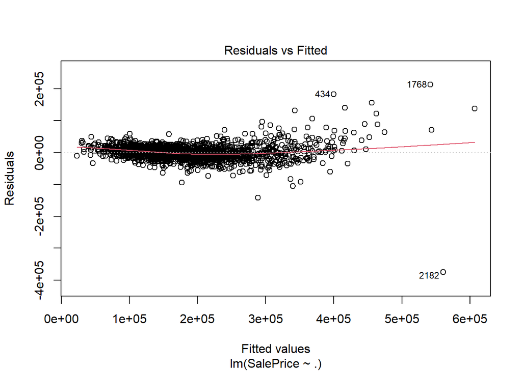

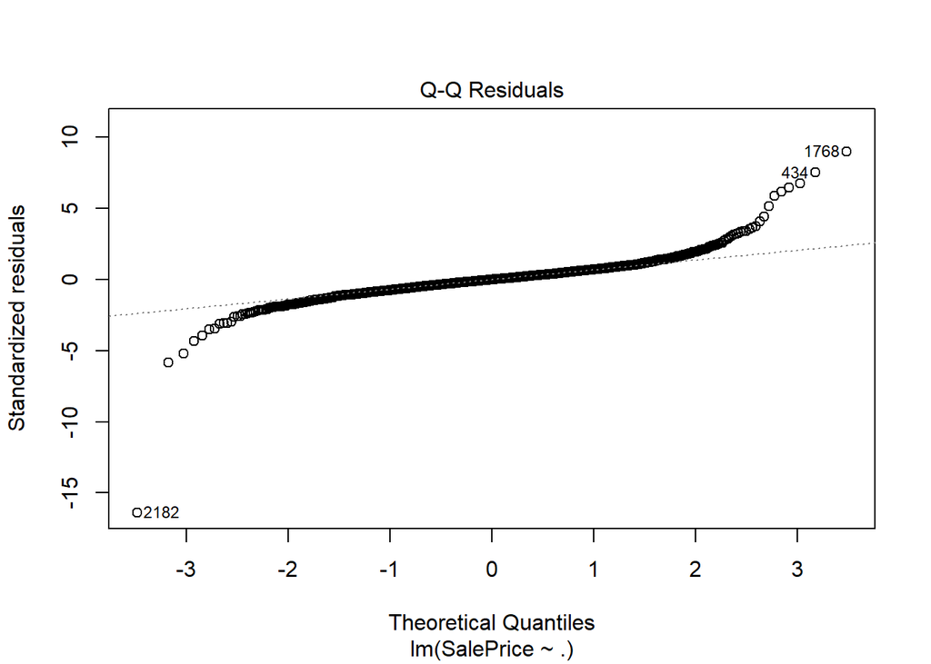

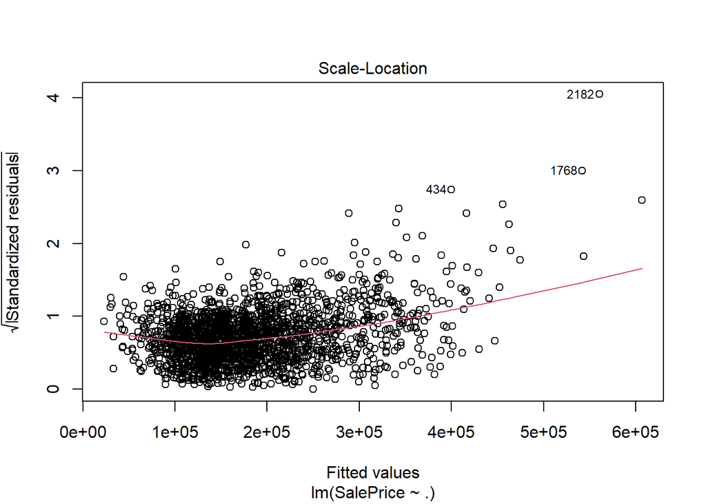

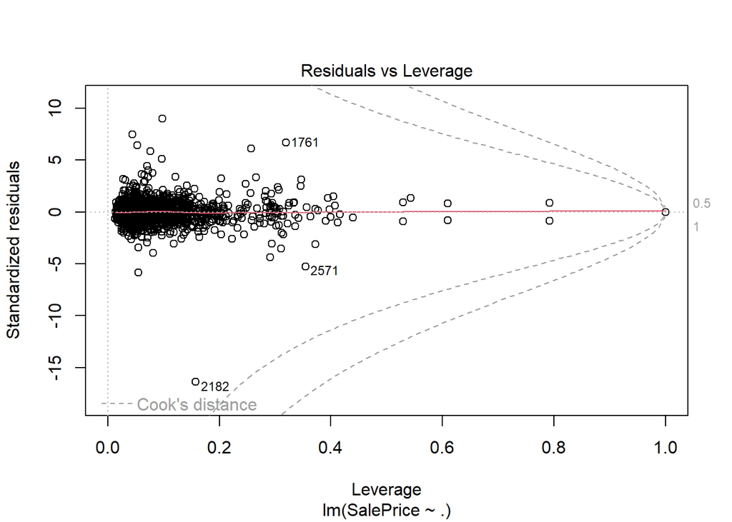

```r
plot(model1)
```

Eventhough the test statistics rejects the null hypothesis in BP test the problem seem to be the outlier values espacially the ones with extreme prices. Our model1 seem to be working fine from the residual plot at least for the houses with normal prices.

If we look at the QQ plot, again we see some problems with the extreme values while we have normality in usual prices. Therefore, the visualizations are provides a big support for our model.

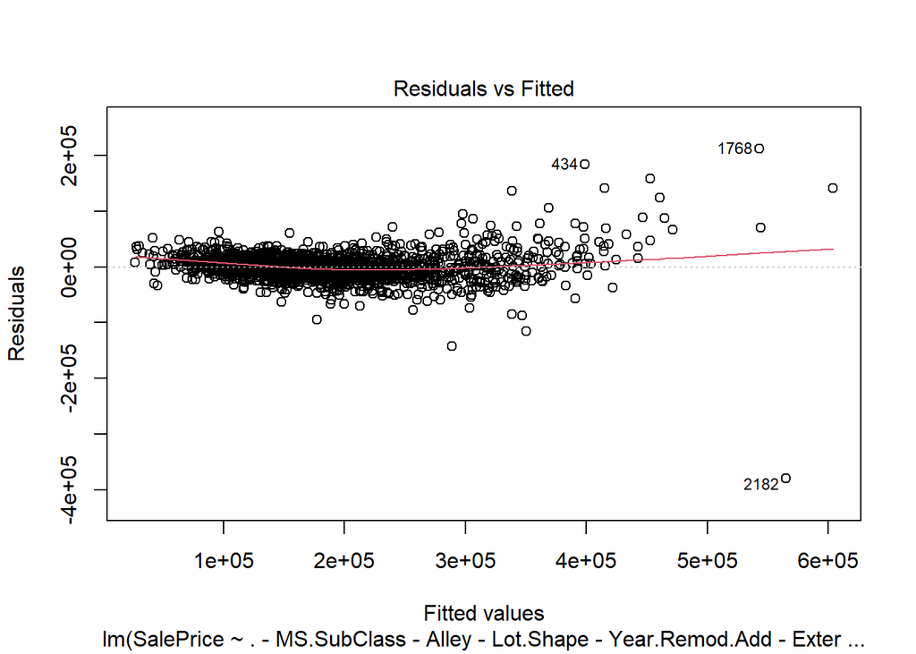

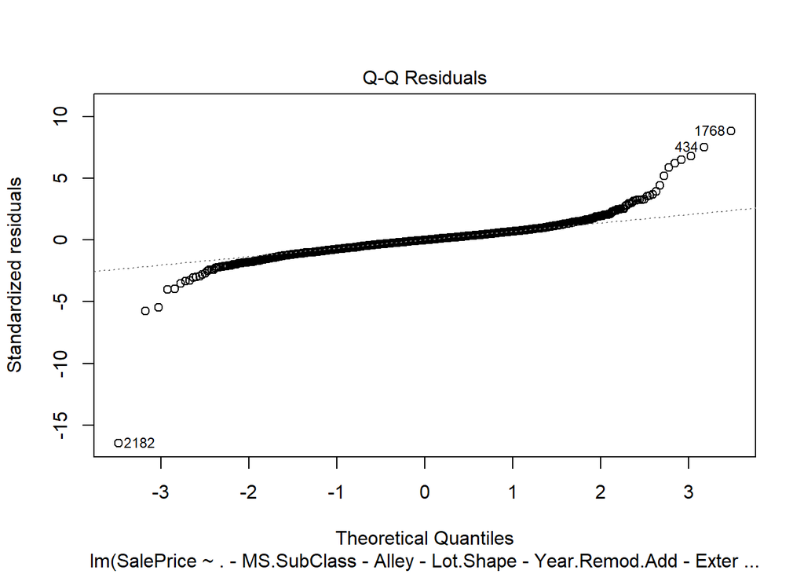

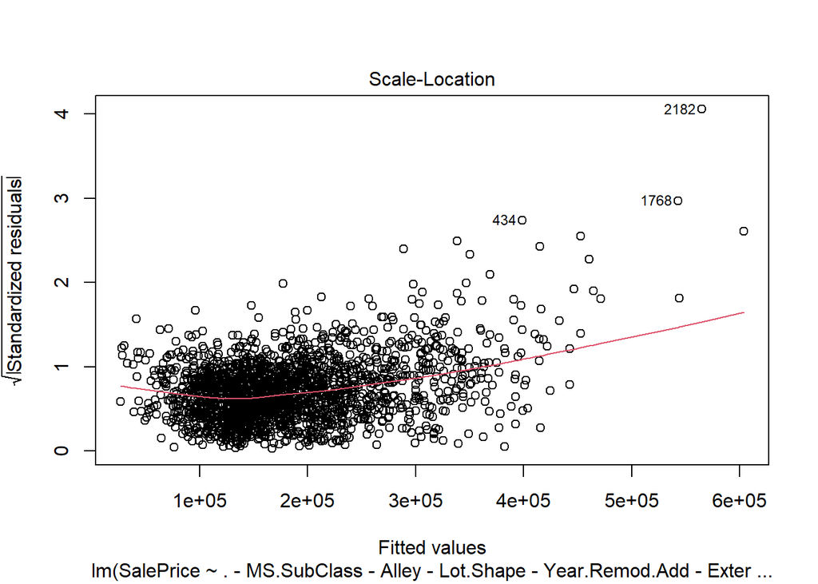

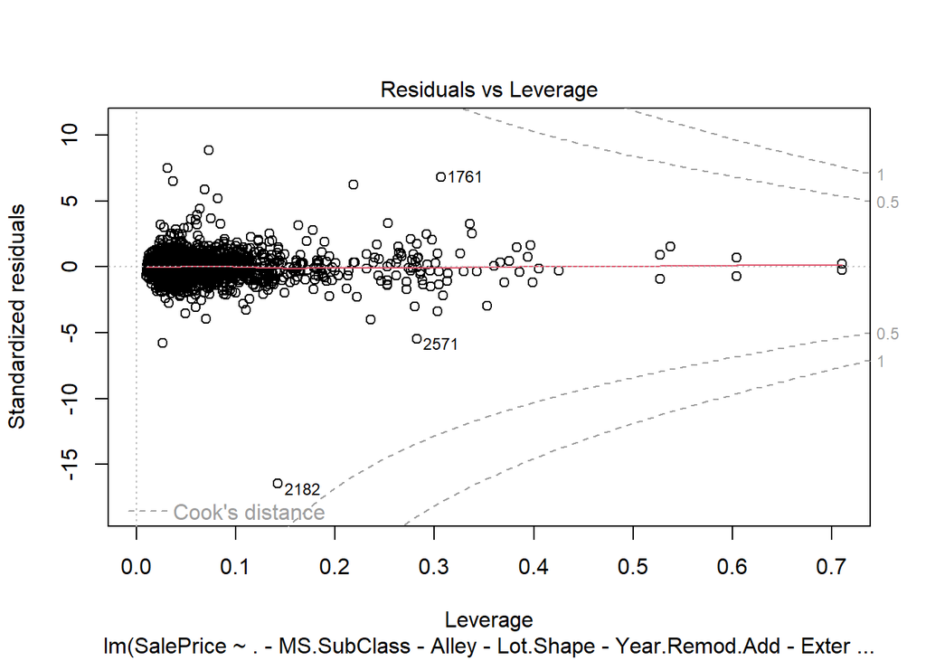

```r
plot(model2)
```

- The same observations can be made also for model 2.

## Predictions of the test set:

Both models are performing similarly. Therefore, we will use model2 for the predictions as it has less variables.

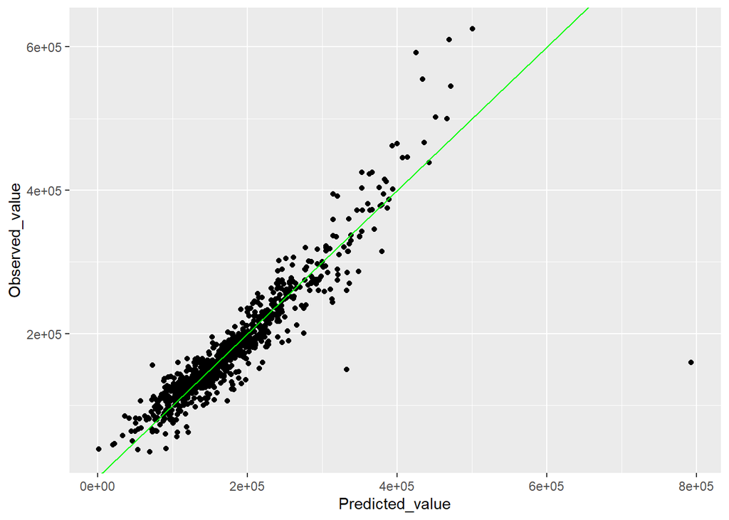

```r
# create dataframe with actual and predicted values
plot_data <- data.frame(Predicted_value = predict(model2, ames_tst_data ),
                       Observed_value = ames_tst_data$SalePrice)

# plot predicted values and actual values
ggplot(plot_data, aes(x = Predicted_value, y = Observed_value)) +
                  geom_point() +
                 geom_abline(intercept = 0, slope = 1, color = "green")
```

- The performance of our model for the test set seems to be good. We again observe some problems with extremely high prices.

# Discussion

The both linear models we built seem to be working similarly. They both fail for BP and Shapiro Wilk Tests. However, the reason behind rejection seem to be the extremly high prices. As they are outliers, it is difficult to predict for those prices. Also, there are some unobservable factors for the extremely high priced houses like prestige, rare luxury etc. Therefore, our models with 90% adjusted R square performs good enough to make predictions on normal priced houses.